# 10b

Yiqiao Yin

3/27/2021

## Problem: 12.3

Hamiltonian Monte Carlo: Program HMC in R for the bioassay logistic regression example from Chapter 3.

- 1. Code the gradients analytically and numerically and check that the two programs give the same result.
- 2. Pick reasonable starting values for the mass matrix, step size, and number of steps.
- 3. Tune the algorithm to an approximate 65% acceptance rate.
- 4. Run 4 chains long enough so that each has an effective sample size of at least 100. How many iterations did you need?
- 5. Check that your inferences are consistent with those from the direct approach in Chapter 3.

### Solution

Let us recall the data.

```r
# Data
x <-  c(-0.86, -0.30, -0.05,  0.73)
y <-  c(0, 1, 3, 5)
n <-  rep(5,4)
```

```r
# ML estimation
mlfit <- glm(cbind(y, n-y) ~ x, family = binomial)
mlfit$coefficients = round(mlfit$coefficients*1000)/1000
res1 = paste(paste("(",mlfit$coefficients[1], sep=""),
             paste(mlfit$coefficients[2],")", sep=""), sep=",")
print(mlfit)
```

```
##
## Call:  glm(formula = cbind(y, n - y) ~ x, family = binomial)
##
## Coefficients:
## (Intercept)            x
##       0.847        7.749
##
## Degrees of Freedom: 3 Total (i.e. Null);  2 Residual
## Null Deviance:       15.79
## Residual Deviance: 0.05474   AIC: 7.965
```

```r
print(res1)
```

```
## [1] "(0.847,7.749)"
```

Instead, let us do Metropolis Algorithm first. Next, we are going to do a HMC algorithm.

```r
# Define function to compute posterior distribution
posterior <- function(arg1) {
  alpha <- arg1[1]
  beta <- arg1[2]
  posterior <-  1

  for (i in 1:length(y)) {
    posterior <-  posterior * (
      ( ( boot::inv.logit( alpha + beta * x[i] ) )^y[i] ) *
        ( ( 1 - boot::inv.logit( alpha + beta * x[i] ) )^( n[i] - y[i] ) )
    )
  }
  posterior
} # End of function

# Define a function draw multivariate gausian
jumping <- function(theta, scale=.1) {
  return(
    mvtnorm::rmvnorm(
      1,
      mean = theta,
      sigma = scale * diag(length(theta))))
}

# Define a function draw multivariate gausian
d.jumping <- function(theta, theta_1, scale=.1) {
  return(
    mvtnorm::dmvnorm(
      theta,
      theta_1,
      scale * diag(length(theta)))
  )
}
```

We can use the above helper function for Metropolis Algorithm.

```r
sims <-  100
theta <-  matrix(0,nrow = sims, ncol = 4)
accept <-  rep(0,sims)
r.all <-  rep(0,sims)
theta[1,] <-  mlfit$coefficients

for (i in 2:sims) {
  theta.star <- jumping(theta[i-1,], .1)
  r <- min(exp((log(posterior(theta.star))) - (log(posterior(theta[i - 1, ])))), 1)
  if (is.nan(r)) {r <- 0}
  r.all[i] <- r
  if (r < runif(1)) {
    theta[i, ] <- theta.star
    accept[i] <- 1
  } else {
    theta[i,] <- theta[i-1,]
    accept[i] <- 0
  }

  sum(accept)
}

print(paste0("Acceptance rate is ", round(sum(accept)/length(accept), 3)))
```

```
## [1] "Acceptance rate is 0.19"
```

To raise the acceptance range to 65% or above, we can use the following:

```r
sims <-  1000
theta <-  matrix(0,nrow = sims, ncol = 4)
accept <-  rep(0,sims)
r.all <-  rep(0,sims)
theta[1,] <-  mlfit$coefficients

for (i in 2:sims) {
  theta.star <- jumping(theta[i-1,], .1)
  r <- min(exp((log(posterior(theta.star))) - (log(posterior(theta[i - 1, ])))), 1)
  if (is.nan(r)) {r <- 0}
  r.all[i] <- r
  if (r < runif(1)) {
    theta[i, ] <- theta.star
    accept[i] <- 1
  } else {
    theta[i,] <- theta[i-1,]
    accept[i] <- 0
  }

  sum(accept)
}

print(paste0("Acceptance rate is ", round(sum(accept)/length(accept), 3)))
```

```
## [1] "Acceptance rate is 0.86"
```

Next, let us do HMC algorithm. First, let us redefine the data.

```r
# Data
head(warpbreaks)
```

```
##   breaks wool tension
## 1     26    A       L
## 2     30    A       L
## 3     54    A       L
## 4     25    A       L
## 5     70    A       L
## 6     52    A       L
```

```r
x <-  c(-0.86, -0.30, -0.05,  0.73)
n <- rep(5,4)
y <-  c(0, 1, 3, 5)
X <- model.matrix(y ~ x*n, data=data.frame(y,x))
```

In order to assist the *hmc()* function that we will use.

```r
# Helper function
linear_posterior <- function(
  theta,
  y,
  X,
  a = 1e-4,
  b = 1e-4,
  sig2beta = 1e3) {
  k <- length(theta)
  beta_param <- as.numeric(theta[1:(k - 1)])
  gamma_param <- theta[k]
  n <- nrow(X)
  result <- -(n / 2 + a) * gamma_param - exp(-gamma_param) / 2 *
    t(y - X %*% beta_param) %*%
    (y - X %*% beta_param) - b * exp(-gamma_param) -
    1 / 2 * t(beta_param) %*% beta_param / sig2beta
  return(result)
}

g_linear_posterior <- function(
  theta, y, X, a = 1e-4, b = 1e-4,
  sig2beta = 1e3) {
  k <- length(theta)
  beta_param <- as.numeric(theta[1:(k-1)])
  gamma_param <- theta[k]
  n <- nrow(X)
  grad_beta <- exp(-gamma_param) * t(X) %*%
    (y - X%*%beta_param) - beta_param / sig2beta
  grad_gamma <- -(n/2 + a) + exp(-gamma_param)/2 *
    t(y - X%*%beta_param) %*%
    (y - X%*%beta_param) + b*exp(-gamma_param)
  c(as.numeric(grad_beta), as.numeric(grad_gamma))
}
```

Let us set up the environment for running HMC algorithm. Let us use two chains for now, so in the function we set *chain = 2*.

```r
N <- 2e3
set.seed(143)
eps_vals <- c(rep(2e-1, 4), 2e-2)
fm1_hmc <- hmclearn::hmc(
  N, theta.init = c(rep(0, 4), 1),
  epsilon = eps_vals, L = 20,
  logPOSTERIOR = linear_posterior,
  glogPOSTERIOR = g_linear_posterior,
  varnames = c(colnames(X), "log_sigma_sq"),
  param = list(y = y, X = X), chains = 2,
  parallel = FALSE)
```

```r
summary(fm1_hmc, burnin=200)
```

```
## Summary of MCMC simulation
```

```
##                     2.5%          5%         25%         50%       75%
## (Intercept)  -37.9957779 -34.8070256 -26.8236041  -8.8501894 14.280076
## x            -84.3390565 -73.1295001 -44.0717235 -14.2929589 11.313046
## n            -11.5808651  -9.4527549  -2.3559877   2.2501201  6.010064
## x:n           -7.9212172  -5.6900124  -1.6650666   3.5253669  9.441472
## log_sigma_sq  -0.1658071  -0.1658071   0.1621788   0.7768779  1.727289
##                    95%     97.5%     rhat
## (Intercept)  49.053222 59.747707 1.030983
## x            31.879048 42.736937 1.903251
## n             7.579825  8.251191 1.031487
## x:n          15.180011 17.498128 1.883210
## log_sigma_sq  3.431356  4.035933 1.004807
```

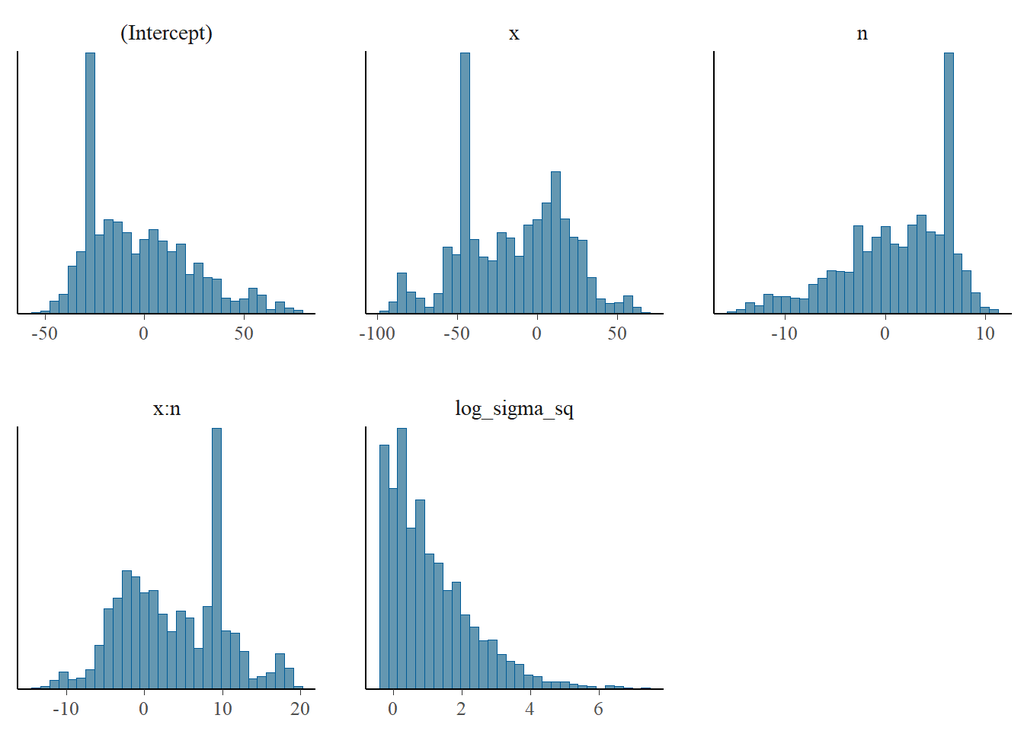

```r
plot(fm1_hmc, burnin=200)
```

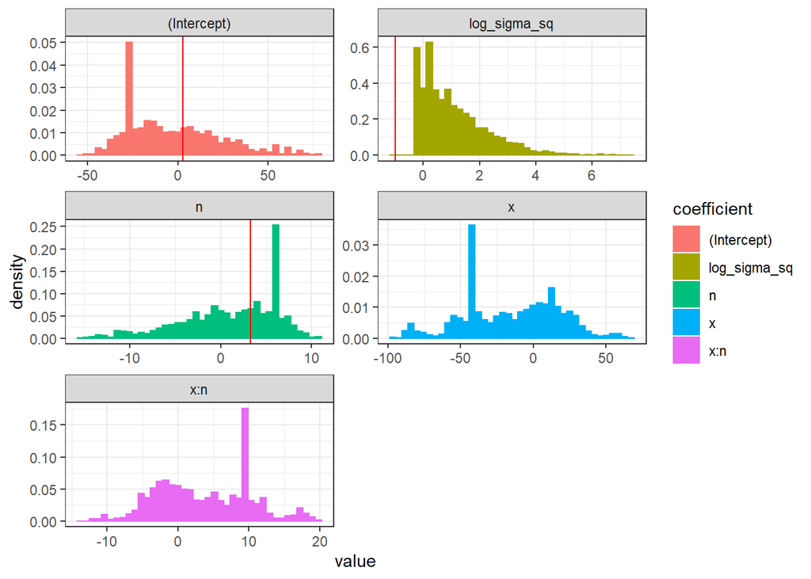

```r
f <- lm(y ~ n*x, data = data.frame(X))
freq.param <- c(coef(f), 2*log(sigma(f)))
hmclearn::diagplots(fm1_hmc, burnin=200, comparison.theta=freq.param)
```

Now, let us try with four chains. Thus, let us set *chain = 4*.

```r
N <- 2e3
set.seed(143)
eps_vals <- c(rep(2e-1, 4), 2e-2)
fm2_hmc <- hmclearn::hmc(
  N, theta.init = c(rep(0, 4), 1),
  epsilon = eps_vals, L = 20,
  logPOSTERIOR = linear_posterior,
  glogPOSTERIOR = g_linear_posterior,
  varnames = c(colnames(X), "log_sigma_sq"),
  param = list(y = y, X = X), chains = 4,
  parallel = FALSE)
```

```r
summary(fm2_hmc, burnin=200)
```

```
## Summary of MCMC simulation
```

```
##                     2.5%          5%         25%         50%       75%
## (Intercept)  -44.1884340 -36.9594698 -23.3892901  -0.7085437 19.205363
## x            -81.4663845 -64.0202067 -39.2038482 -15.1679380  8.030355
## n            -12.3209073  -9.9592579  -3.2862171   0.6422773  5.150468
## x:n           -6.6393985  -5.0621471  -0.9335142   3.7198658  8.558204
## log_sigma_sq  -0.1658071  -0.1658071   0.2212726   0.8596903  1.911706
##                    95%     97.5%     rhat
## (Intercept)  52.000605 64.023653 1.084914
## x            28.846036 36.192217 1.308339
## n             8.004463  9.496728 1.085264
## x:n          13.619459 17.053833 1.302837
## log_sigma_sq  3.854486  4.742797 1.012458
```

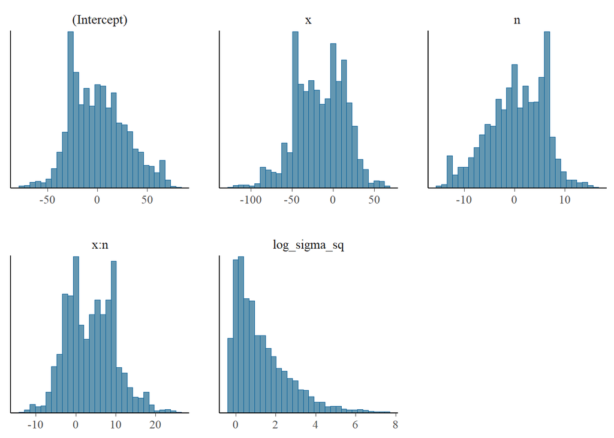

```r
plot(fm2_hmc, burnin=200)
```

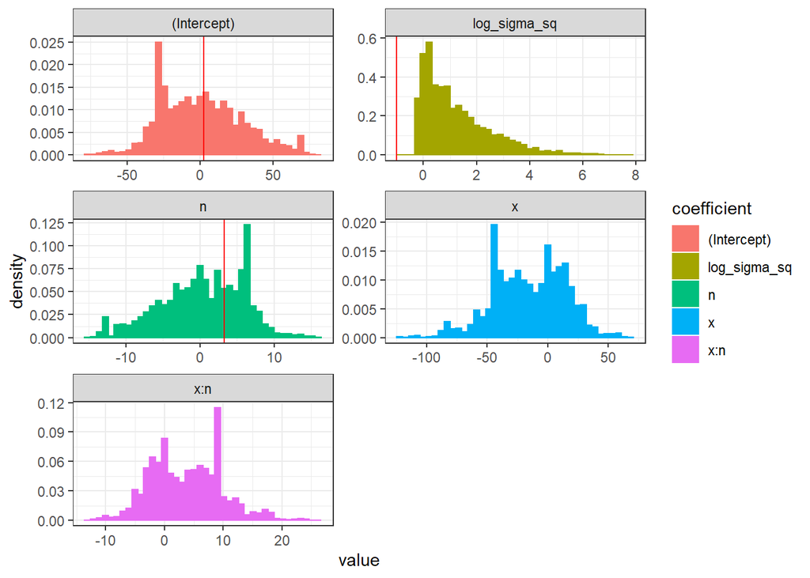

```r
f <- lm(y ~ n*x, data = data.frame(X))
freq.param <- c(coef(f), 2*log(sigma(f)))
hmclearn::diagplots(fm2_hmc, burnin=200, comparison.theta=freq.param)
```